# Lab 1: Recurrent, Convolutional and Bidirectional Neural Networks

#### Transformers workshop

In this practical, we will apply RNN and CNN deep learning architectures on text sequence data. We will be going to use the **Drug Review Dataset** from drugs.com which is publicly availabe at the UCI Machine Learning repository. Below more information on the dataset:

- The Drug Review Dataset provides patient reviews on specific drugs along with related conditions and a 10-star patient rating reflecting the overall patient satisfaction.
- The data was obtained by crawling online pharmaceutical review sites.
- The dataset is of shape (161297, 7) i.e. It has 7 features including the review and 161297 Data Points or entries.
- The features are 'drugName' which is the name of the drug, 'condition' which is the condition the patient is suffering from, 'review' is the patients review, 'rating' is the 10-star patient rating for the drug, 'date' is the date of the entry and the 'usefulcount' is the number of users who found the review usefule.

**Let's first load the following libraries. Take care to have them installed!**

```python
from sklearn.feature_extraction.text import TfidfVectorizer
from sklearn.model_selection import RandomizedSearchCV
from sklearn.preprocessing import LabelEncoder

from keras.utils import pad_sequences
from keras.preprocessing.text import Tokenizer
from keras.models import Sequential
from keras import layers, utils

from scikeras.wrappers import KerasClassifier
import matplotlib.pyplot as plt
from wordcloud import WordCloud
import tensorflow as tf
import seaborn as sns
import pandas as pd
import numpy as np
import random
```

```
WARNING:tensorflow:From C:\Python\Python311\Lib\site-packages\keras\src\losses.py:2976: The name tf.losses.sparse_softmax_cross_entropy is deprecated. Please use tf.compat.v1.losses.sparse_softmax_cross_entropy instead.
```

```python
# set the seeds so we might be able to get the same results!
seed = 137
random.seed(seed)
np.random.seed(seed)
tf.random.set_seed(seed)
```

### Data exploration and visualization

**1. Load the train and test sets from the data folder.**

```python
df_train = pd.read_csv("data/drugsComTrain_raw.tsv",sep='\t')
df_train.head()
```

|  | Unnamed: 0 | drugName | condition | review | rating | date | usefulCount |
| --- | --- | --- | --- | --- | --- | --- | --- |
| 0 | 206461 | Valsartan | Left Ventricular Dysfunction | "It has no side effect, I take it in combinati... | 9.0 | May 20, 2012 | 27 |
| 1 | 95260 | Guanfacine | ADHD | "My son is halfway through his fourth week of ... | 8.0 | April 27, 2010 | 192 |
| 2 | 92703 | Lybrel | Birth Control | "I used to take another oral contraceptive, wh... | 5.0 | December 14, 2009 | 17 |
| 3 | 138000 | Ortho Evra | Birth Control | "This is my first time using any form of birth... | 8.0 | November 3, 2015 | 10 |
| 4 | 35696 | Buprenorphine / naloxone | Opiate Dependence | "Suboxone has completely turned my life around... | 9.0 | November 27, 2016 | 37 |

```python
df_test = pd.read_csv("data/drugsComTest_raw.tsv",sep='\t')
df_test.head()
```

|  | Unnamed: 0 | drugName | condition | review | rating | date | usefulCount |
| --- | --- | --- | --- | --- | --- | --- | --- |
| 0 | 163740 | Mirtazapine | Depression | "I&#039;ve tried a few antidepressants over th... | 10.0 | February 28, 2012 | 22 |
| 1 | 206473 | Mesalamine | Crohn's Disease, Maintenance | "My son has Crohn&#039;s disease and has done ... | 8.0 | May 17, 2009 | 17 |
| 2 | 159672 | Bactrim | Urinary Tract Infection | "Quick reduction of symptoms" | 9.0 | September 29, 2017 | 3 |
| 3 | 39293 | Contrave | Weight Loss | "Contrave combines drugs that were used for al... | 9.0 | March 5, 2017 | 35 |
| 4 | 97768 | Cyclafem 1 / 35 | Birth Control | "I have been on this birth control for one cyc... | 9.0 | October 22, 2015 | 4 |

**2. Check the number of reviews in train and test sets and the number of drug names.**

```python
df_train.shape
```

```
(161297, 7)
```

```python
df_test.shape
```

```
(53766, 7)
```

```python
len(df_train['drugName'].unique().tolist())
```

```
3436
```

```python
len(df_test['drugName'].unique().tolist())
```

```
2637
```

**3. Let's explore the data by the following wordcloud and barchart plots.**

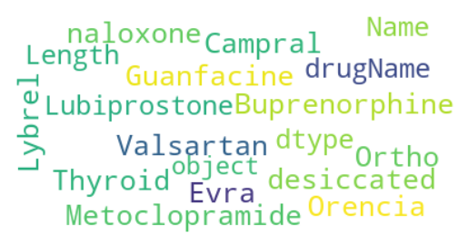

```python
# let's see the words cloud for the reviews
# most popular drugs
wordcloud = WordCloud(max_font_size = 25, max_words = 50, background_color = "white").generate(str(df_train['drugName']))
plt.figure()
plt.imshow(wordcloud, interpolation = "bilinear")
plt.axis("off")
plt.show()
```

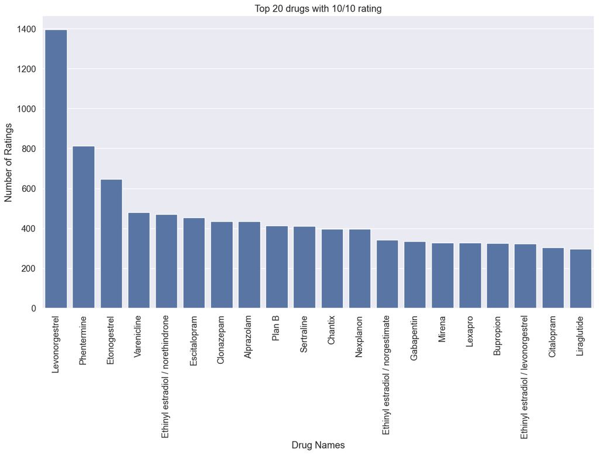

```python
# This barplot shows the top 20 drugs with the 10/10 rating
# Setting the Parameter
sns.set(font_scale = 1.2, style = 'darkgrid')
plt.rcParams['figure.figsize'] = [15, 8]

rating = dict(df_train.loc[df_train.rating == 10, "drugName"].value_counts())
drugname = list(rating.keys())
drug_rating = list(rating.values())

sns_rating = sns.barplot(x = drugname[0:20], y = drug_rating[0:20])

sns_rating.set_title('Top 20 drugs with 10/10 rating')
sns_rating.set_ylabel("Number of Ratings")
sns_rating.set_xlabel("Drug Names")
plt.setp(sns_rating.get_xticklabels(), rotation=90);
```

**4. Convert the rating into three labels: positive, negative and neutral for the sentiment classification task.**

```python
df_train['label'] = 'neutral'
df_train.loc[df_train['rating'] >= 6, 'label'] = 'positive'
df_train.loc[df_train['rating'] <= 4, 'label'] = 'negative'
df_train.head()
```

|  | Unnamed: 0 | drugName | condition | review | rating | date | usefulCount | label |
| --- | --- | --- | --- | --- | --- | --- | --- | --- |
| 0 | 206461 | Valsartan | Left Ventricular Dysfunction | "It has no side effect, I take it in combinati... | 9.0 | May 20, 2012 | 27 | positive |
| 1 | 95260 | Guanfacine | ADHD | "My son is halfway through his fourth week of ... | 8.0 | April 27, 2010 | 192 | positive |
| 2 | 92703 | Lybrel | Birth Control | "I used to take another oral contraceptive, wh... | 5.0 | December 14, 2009 | 17 | neutral |
| 3 | 138000 | Ortho Evra | Birth Control | "This is my first time using any form of birth... | 8.0 | November 3, 2015 | 10 | positive |
| 4 | 35696 | Buprenorphine / naloxone | Opiate Dependence | "Suboxone has completely turned my life around... | 9.0 | November 27, 2016 | 37 | positive |

```python
df_test['label'] = 'neutral'
df_test.loc[df_test['rating'] >= 6, 'label'] = 'positive'
df_test.loc[df_test['rating'] <= 4, 'label'] = 'negative'
df_test.head()
```

|  | Unnamed: 0 | drugName | condition | review | rating | date | usefulCount | label |
| --- | --- | --- | --- | --- | --- | --- | --- | --- |
| 0 | 163740 | Mirtazapine | Depression | "I&#039;ve tried a few antidepressants over th... | 10.0 | February 28, 2012 | 22 | positive |
| 1 | 206473 | Mesalamine | Crohn's Disease, Maintenance | "My son has Crohn&#039;s disease and has done ... | 8.0 | May 17, 2009 | 17 | positive |
| 2 | 159672 | Bactrim | Urinary Tract Infection | "Quick reduction of symptoms" | 9.0 | September 29, 2017 | 3 | positive |
| 3 | 39293 | Contrave | Weight Loss | "Contrave combines drugs that were used for al... | 9.0 | March 5, 2017 | 35 | positive |
| 4 | 97768 | Cyclafem 1 / 35 | Birth Control | "I have been on this birth control for one cyc... | 9.0 | October 22, 2015 | 4 | positive |

**5. More preprocessing.**

First run the following lines to make your data ready for the models (we used this code in the previous practical):

```python
# tokenizer from keras
tokenizer = Tokenizer(num_words = 20000)
tokenizer.fit_on_texts(df_train.review.values)
X_train = tokenizer.texts_to_sequences(df_train.review.values)
X_test  = tokenizer.texts_to_sequences(df_test.review.values)
vocab_size = len(tokenizer.word_index) + 1  # Adding 1 because of reserved 0 index for sequence padding

# pad sequence
maxlen  = 100
X_train = pad_sequences(X_train, padding = 'post', maxlen = maxlen)
X_test  = pad_sequences(X_test,  padding = 'post', maxlen = maxlen)

# One-hot encoding the labels
lb = LabelEncoder()
y = lb.fit_transform(df_train.label.values)
y_train = utils.to_categorical(y)
y = lb.transform(df_test.label.values)
y_test = utils.to_categorical(y)
```

Let's use the code below which is a function for plotting the history of training of our neural network models:

```python
plt.style.use('ggplot')
def plot_history(history, val=0):
    acc = history.history['accuracy']
    if val == 1:
        val_acc = history.history['val_accuracy'] # we can add a validation set in our fit function with nn
    loss = history.history['loss']
    if val == 1:
        val_loss = history.history['val_loss']
    x = range(1, len(acc) + 1)

    plt.figure(figsize=(12, 5))
    plt.subplot(1, 2, 1)
    plt.plot(x, acc, 'b', label='Training accuracy')
    if val == 1:
        plt.plot(x, val_acc, 'r', label='Validation accuracy')
    plt.ylabel('accuracy')
    plt.xlabel('epoch')
    plt.title('Accuracy')
    plt.legend()
    plt.subplot(1, 2, 2)
    plt.plot(x, loss, 'b', label='Training loss')
    if val == 1:
        plt.plot(x, val_loss, 'r', label='Validation loss')
    plt.ylabel('loss')
    plt.xlabel('epoch')
    plt.title('Loss')
    plt.legend()
```

### Recurrent neural networks

A recurrent neural network (RNN) is a natural generalization of feed-forward neural networks to sequence data such as text. In contrast to a feed-forward neural network, however, it accepts a new input at every time step (layer). Long-short term memory (LSTM) networks are a variant of RNNs. The LSTM introduces mechanisms to decide what should be remembered and what should be forgotten in learning from text documents.

```python
embedding_dim = 100
model_rnn = Sequential()
model_rnn.add(layers.Embedding(vocab_size, embedding_dim, input_length = maxlen))
model_rnn.add(layers.LSTM(100, dropout = 0.2, recurrent_dropout = 0.2))
model_rnn.add(layers.Dense(10, activation = 'relu'))
model_rnn.add(layers.Dense(3, activation = 'softmax'))
model_rnn.compile(optimizer = 'adam',
              loss = 'categorical_crossentropy',
              metrics = ['accuracy'])
model_rnn.summary()
```

```
WARNING:tensorflow:From C:\Python\Python311\Lib\site-packages\keras\src\backend.py:873: The name tf.get_default_graph is deprecated. Please use tf.compat.v1.get_default_graph instead.

WARNING:tensorflow:From C:\Python\Python311\Lib\site-packages\keras\src\optimizers\__init__.py:309: The name tf.train.Optimizer is deprecated. Please use tf.compat.v1.train.Optimizer instead.

Model: "sequential"
_________________________________________________________________
 Layer (type)                Output Shape              Param #
=================================================================
 embedding (Embedding)       (None, 100, 100)          5143000

 lstm (LSTM)                 (None, 100)               80400

 dense (Dense)               (None, 10)                1010

 dense_1 (Dense)             (None, 3)                 33

=================================================================
Total params: 5224443 (19.93 MB)
Trainable params: 5224443 (19.93 MB)
Non-trainable params: 0 (0.00 Byte)
_________________________________________________________________
```

**7. Fit the model in 5 epochs.**

```python
history_rnn = model_rnn.fit(X_train, y_train,
                        epochs = 5,
                        verbose = True,
                        validation_split = 0.1,
                        batch_size = 64)
```

[output not shown]

**8. Evaluate the accuracy of your model on the test set and plot the history of fit.**

```
Testing Accuracy:  0.8542
```

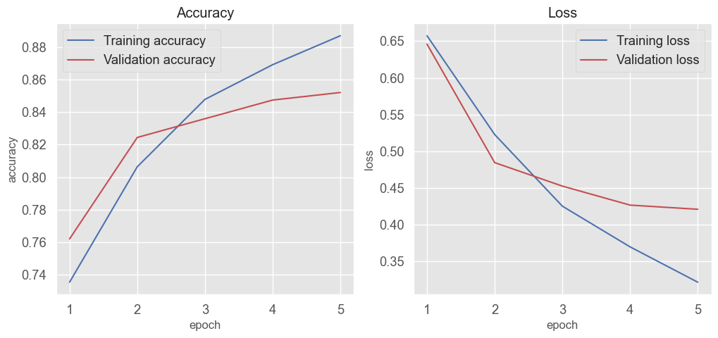

```python
loss, accuracy = model_rnn.evaluate(X_test, y_test, verbose = True)
print("Testing Accuracy:  {:.4f}".format(accuracy))
plot_history(history_rnn, val = 1)
```

### Convolutional neural networks

Convolutional neural networks or also called convnets are one of the most exciting developments in machine learning in recent years. They have revolutionized image classification and computer vision by being able to extract features from images and using them in neural networks. The properties that made them useful in image processing makes them also handy for sequence processing. When you are working with sequential data, like text, you work with one dimensional convolutions, but the idea and the application stays the same.

```python
model_cnn = Sequential()
model_cnn.add(layers.Embedding(vocab_size, embedding_dim, input_length = maxlen))
model_cnn.add(layers.Conv1D(128, 5, activation = 'relu'))
model_cnn.add(layers.GlobalMaxPooling1D())
model_cnn.add(layers.Dense(10, activation = 'relu'))
model_cnn.add(layers.Dense(3, activation = 'softmax'))
model_cnn.compile(optimizer = 'adam',
                  loss = 'binary_crossentropy',
                  metrics = ['accuracy'])
model_cnn.summary()
```

```
Model: "sequential_1"
_________________________________________________________________
 Layer (type)                Output Shape              Param #
=================================================================
 embedding_1 (Embedding)     (None, 100, 100)          5143000

 conv1d (Conv1D)             (None, 96, 128)           64128

 global_max_pooling1d (Glob  (None, 128)               0
 alMaxPooling1D)

 dense_2 (Dense)             (None, 10)                1290

 dense_3 (Dense)             (None, 3)                 33

=================================================================
Total params: 5208451 (19.87 MB)
Trainable params: 5208451 (19.87 MB)
Non-trainable params: 0 (0.00 Byte)
_________________________________________________________________
```

**10. Fit the model in 5 epochs, and evaluate the accuracy of the test data using your model. Plot the history of the fit.**

```python
history_cnn = model_cnn.fit(X_train, y_train,
                        epochs = 5,
                        verbose = True,
                        validation_split = 0.1,
                        batch_size = 64)
```

```
Testing Accuracy:  0.8944
```

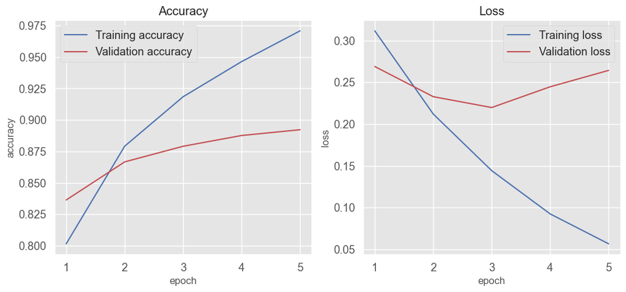

```python
loss, accuracy = model_cnn.evaluate(X_test, y_test, verbose = True)
print("Testing Accuracy:  {:.4f}".format(accuracy))
plot_history(history_cnn, val = 1)
```

### Bidirectional recurrent neural networks

Bidirectional recurrent neural networks are neural networks that process input data in both the forward and backward directions. This time we will create our arctitechture based on the GRU (Gated Recurrent Unit) cells. Introduced by Cho, et al. in 2014, GRU aims to solve the vanishing gradient problem which comes with a standard recurrent neural network. GRU's are a variation on the LSTM because both are designed similarly and, in some cases, produce equally excellent results. GRU's were designed to be simpler and faster than LSTM's and in most cases produce equally good results and thus there is no clear winner.

**11. Repeat the analysis with a Bidirectional recurrent neural network using GRU.**

```python
model_brnn = Sequential()
model_brnn.add(layers.Embedding(vocab_size, embedding_dim, input_length=maxlen))
model_brnn.add(layers.Bidirectional(layers.GRU(300)))
model_brnn.add(layers.Dense(10, activation = 'relu'))
model_brnn.add(layers.Dense(3, activation = 'softmax'))
model_brnn.compile(optimizer = 'adam',
                   loss = 'categorical_crossentropy',
                   metrics = ['accuracy'])
model_brnn.summary()
```

```
Model: "sequential_2"
_________________________________________________________________
 Layer (type)                Output Shape              Param #
=================================================================
 embedding_2 (Embedding)     (None, 100, 100)          5143000

 bidirectional (Bidirection  (None, 600)               723600
 al)

 dense_4 (Dense)             (None, 10)                6010

 dense_5 (Dense)             (None, 3)                 33

=================================================================
Total params: 5872643 (22.40 MB)
Trainable params: 5872643 (22.40 MB)
Non-trainable params: 0 (0.00 Byte)
_________________________________________________________________
```

```python
history_brnn = model_brnn.fit(X_train, y_train,
                              epochs = 5,
                              verbose = True,
                              validation_split = 0.1,
                              batch_size = 64)
```

```
Testing Accuracy:  0.8758
```

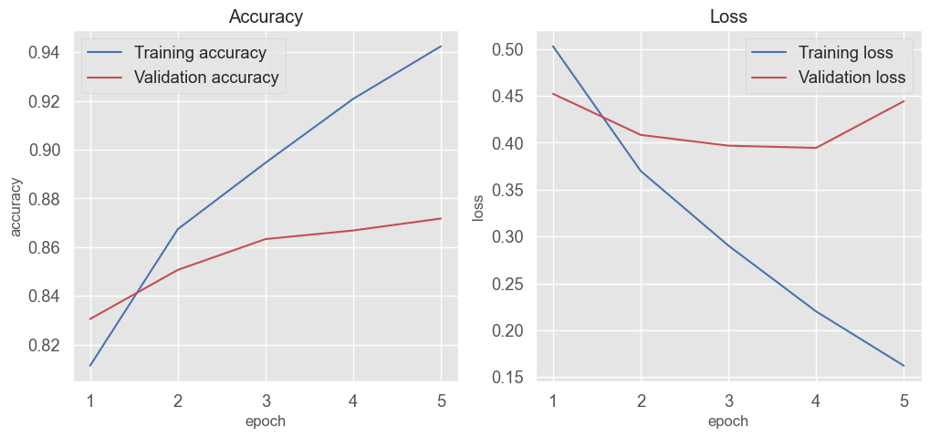

```python
loss, accuracy = model_brnn.evaluate(X_test, y_test, verbose = True)
print("Testing Accuracy:  {:.4f}".format(accuracy))
plot_history(history_brnn, val = 1)
```

# Hyperparameter optimization (optional)

One crucial steps of deep learning and working with neural networks is hyperparameter optimization. Hyperparameters are parameters that are chosen by the algorithm designer. Tuning them is very important! One popular method for hyperparameter optimization is grid search. What this method does is it takes lists of parameters and it runs the model with each parameter combination that it can find. It is the most thorough way but also the most computationally heavy way to do this. Another common way, random search, which you’ll see in action here, simply takes random combinations of parameters.

**12. Write function for creating your cnn-based model which has the number of filters, kernel size, and embedding size as input arguments. Name your function `create_model`. For the rest follow the architecture of your previous cnn model.**

```python
def create_model(num_filters, kernel_size, embedding_dim):
    model = Sequential()
    model.add(layers.Embedding(vocab_size, embedding_dim, input_length = 100))
    model.add(layers.Conv1D(num_filters, kernel_size, activation = 'relu'))
    model.add(layers.GlobalMaxPooling1D())
    model.add(layers.Dense(10, activation = 'relu'))
    model.add(layers.Dense(3, activation = 'sigmoid'))
    model.compile(optimizer = 'adam',
                  loss = 'binary_crossentropy',
                  metrics = ['accuracy'])
    return model
```

**13. Dictionary in Python is an ordered collection of data values. Use the dict structure to define your hyperparameters for the cnn model. You can include the number of filters and kernel size as examples.**

```python
param_grid = dict(num_filters = [32, 64],
                  kernel_size = [3, 5])
```

When constructing this structure you must provide a dictionary of hyperparameters to evaluate in the param_grid argument. This is a map of the model parameter name and an array of values to try.

```python
# Parameter grid for grid search
# Hyperparameters to be tuned need to be added as arguments to KerasClassifier from scikeras (https://adriangb.com/scikeras/stable/migration.html#default-arguments-in-build-fn-model)
model = KerasClassifier(model = create_model,
                        epochs = 5,
                        batch_size = 64,
                        num_filters = 32, # hyperparameter 1
                        kernel_size = 3, # hyperparameter 2
                        embedding_dim = 50, # hyperparameter 3
                        verbose = True)
```

**15. Time to call the `RandomizedSearchCV` function. Use your model, your selected grid for hyperparameters, and 5-fold cross-validation.**

```python
grid = RandomizedSearchCV(estimator = model,
                          param_distributions = param_grid,
                          cv = 5,
                          n_jobs = -1,
                          verbose = 1,
                          n_iter = 2)
```

As you see in this function, there are more input arguments which you can set including `n_jobs` and `n_iter`. By default, the random search (or grid search) will only use one thread. By setting the `n_jobs` argument in the `RandomizedSearchCV` (or `GridSearchCV`) constructor to -1, the process will use all cores on your machine. It is also worth mentioning that by default, accuracy is the score that is optimized, but other scores can be specified in the `score` argument of the `GridSearchCV` constructor.

**16. Fit your grid on `X_train` and `y_train`.**

```python
grid_result = grid.fit(X_train, y_train)
```

```
Fitting 5 folds for each of 2 candidates, totalling 10 fits
```

**17. Find the best scores and the best values for the hyperparameters.**

```python
print(grid_result.best_score_)
print(grid_result.best_params_)
```

```
0.8723844470072674
{'num_filters': 64, 'kernel_size': 3}
```

The `best_score_` attribute provides access to the best score observed during the optimization procedure and the `best_params_` attribute shows the combination of parameters that achieved the best results.

**18. Evaluate the performance on the test set.**

```python
test_accuracy = grid.score(X_test, y_test)
test_accuracy
```

```
0.8807610757727932
```

**Now you can use the best hyperparameter values to build your final model.**